# Deque Data Structure

Deque atau Double Ended Queue adalah versi umum dari struktur data Queue yang memungkinkan penyisipan dan penghapusan di kedua ujungnya. Berikut adalah contoh program deque dalam berbagai bahasa.

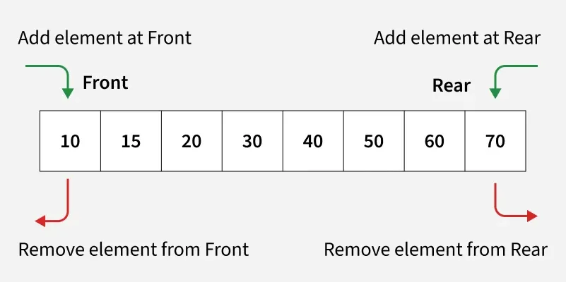

- Deque dapat berfungsi sebagai Stack dan Queue.
- Ini berguna dalam banyak masalah di mana kita perlu memiliki subset dari semua operasi, seperti sisipkan/hapus di depan dan sisipkan/hapus di akhir.
- Implementasinya biasanya dilakukan dengan menggunakan daftar berantai ganda atau array melingkar.

## Deque in Python

Deque adalah singkatan dari Double-Ended Queue (Antrean Dua Ujung). Ini adalah jenis struktur data khusus yang memungkinkan Anda untuk menambahkan dan menghapus elemen dari kedua ujungnya secara efisien. Hal ini membuatnya berguna dalam aplikasi seperti penjadwalan tugas, masalah jendela geser, dan pemrosesan data waktu nyata.

```python
from collections import deque

# Declaring deque
de = deque(['name','age','DOB'])

print(de)
```

```
deque(['name', 'age', 'DOB'])
```

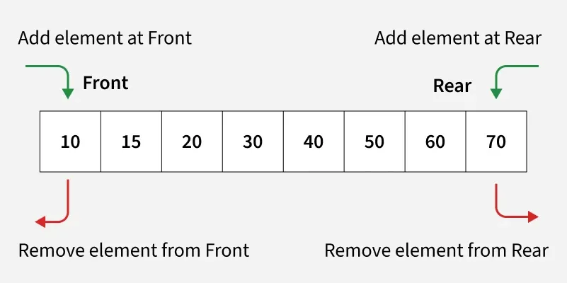

### Mengapa Kita Membutuhkan Deque?

- Ini mendukung waktu O(1) untuk menambahkan/menghapus elemen dari kedua ujung.
- Ini lebih efisien daripada daftar untuk operasi front-end.
- Ia dapat berfungsi sebagai antrian (FIFO) dan tumpukan (LIFO).
- Ideal untuk penjadwalan, masalah jendela geser, dan pemrosesan data waktu nyata.
- Ia menawarkan metode bawaan yang ampuh seperti appendleft() , popleft() , dan rotate().

### Jenis Input Deque Terbatas

1. Deque dengan Batasan Input : Input dibatasi di satu ujung, sedangkan penghapusan diperbolehkan di kedua ujung.
2. Deque dengan Batasan Keluaran : keluaran dibatasi di satu ujung tetapi penyisipan diperbolehkan di kedua ujung.

### Menambahkan dan Menghapus Item Dequeue

- append(x): Menambahkan x ke ujung kanan deque.
- appendleft(x): Menambahkan x ke ujung kiri deque.
- extend(iterable): Menambahkan semua elemen dari iterable ke ujung kanan.
- extendleft(iterable): Menambahkan semua elemen dari iterable ke ujung kiri (dalam urutan terbalik).
- remove(value): Menghapus kemunculan pertama dari nilai yang ditentukan dari deque. Jika nilai tidak ditemukan, akan muncul ValueError.
- pop(): Menghapus dan mengembalikan elemen dari ujung kanan.
- popleft(): Menghapus dan mengembalikan elemen dari ujung kiri.
- clear(): Menghapus semua elemen dari deque.

```python
from collections import deque

dq = deque([10, 20, 30])

# Add elements to the right
dq.append(40)

# Add elements to the left
dq.appendleft(5)

# extend(iterable)
dq.extend([50, 60, 70])
print("After extend([50, 60, 70]):", dq)

# extendleft(iterable)
dq.extendleft([0, 5])
print("After extendleft([0, 5]):", dq)

# remove method
dq.remove(20)
print("After remove(20):", dq)

# Remove elements from the right
dq.pop()

# Remove elements from the left
dq.popleft()

print("After pop and popleft:", dq)

# clear() - Removes all elements from the deque
dq.clear()  # deque: []
print("After clear():", dq)
```

```
After extend([50, 60, 70]): deque([5, 10, 20, 30, 40, 50, 60, 70])
After extendleft([0, 5]): deque([5, 0, 5, 10, 20, 30, 40, 50, 60, 70])
After remove(20): deque([5, 0, 5, 10, 30, 40, 50, 60, 70])
After pop and popleft: deque([0, 5, 10, 30, 40, 50, 60])
After clear(): deque([])
```

### Mengakses Item dan panjang deque

- **Pengindeksan**: Mengakses elemen berdasarkan posisi menggunakan indeks positif atau negatif.
- **len()**: Mengembalikan jumlah elemen dalam deque.

```python
import collections

dq = collections.deque([1, 2, 3, 3, 4, 2, 4])

# Accessing elements by index
print(dq[0])
print(dq[-1])

# Finding the length of the deque
print(len(dq))
```

```
1
4
7
```

### Hitungan, Rotasi, dan Pembalikan sebuah deque

- count(value): Metode ini menghitung jumlah kemunculan elemen tertentu dalam deque.
- rotate(n): Metode ini memutar deque sebanyak n langkah. n positif memutar ke kanan dan n negatif memutar ke kiri.
- reverse(): Metode ini membalik urutan elemen dalam deque.

```python
from collections import deque

# Create a deque
dq = deque([10, 20, 30, 40, 50, 20, 30, 20])

# 1. Counting occurrences of a value
print(dq.count(20))  # Occurrences of 20
print(dq.count(30))  # Occurrences of 30

# 2. Rotating the deque
dq.rotate(2)  # Rotate the deque 2 steps to the right
print(dq)

dq.rotate(-3)  # Rotate the deque 3 steps to the left
print(dq)

# 3. Reversing the deque
dq.reverse()  # Reverse the deque
print(dq)
```

```
3
2
deque([30, 20, 10, 20, 30, 40, 50, 20])
deque([20, 30, 40, 50, 20, 30, 20, 10])
deque([10, 20, 30, 20, 50, 40, 30, 20])
```

## Implementation of Deque using circular array

Deque (Double Ended Queue) adalah versi umum dari struktur data Queue yang memungkinkan penyisipan dan penghapusan elemen dari kedua ujung (depan dan belakang).

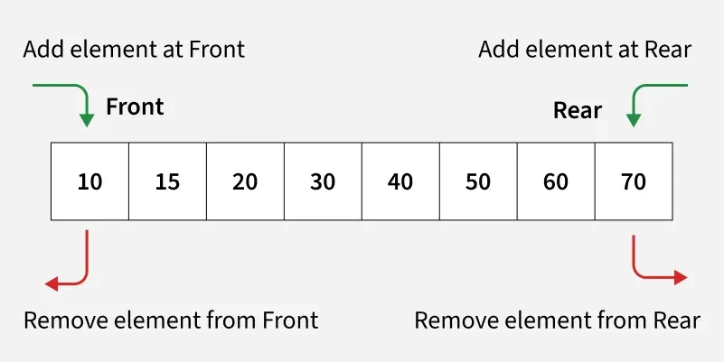

### Operasi pada Deque:

- insertFront() : Menambahkan item di bagian depan Deque
- insertRear() : Menambahkan item di bagian belakang Deque.
- deleteFront() : Menghapus item dari bagian depan Deque.
- deleteRear() : Menghapus item dari bagian belakang Deque.
- frontEle() : Mengambil item terdepan dari antrian.
- RearEle() : Mengambil item terakhir dari antrian.

[figure not shown]

> Catatan: Semua operasi membutuhkan waktu O(1), dan ruang O(n) diperlukan untuk menyimpan elemen.

### Implementasi Deque menggunakan array melingkar

Untuk mengimplementasikan deque, kita memelihara dua indeks: front dan rear .

- Kita dapat memasukkan (menantrekan/mendorong) elemen di bagian depan atau belakang.
- Kita dapat menghapus (dequeue/pop) elemen dari sisi depan atau sisi belakang.

Bekerja:

Sisipkan Elemen di Ujung Belakang Deque:

- Pertama-tama kita periksa apakah deque sudah penuh atau belum.
- Jika ukuran == kapasitas,

kembalikan (deque penuh)

- Atau hitung indeks belakang: belakang = (depan + ukuran) % kapasitas
- Masukkan elemen ke dalam arr[belakang] = kunci
- Tingkatkan ukuran sebanyak 1

ukuran++

```python
def insertRear(self, key):
    if self.size == self.capacity:
        print("Deque is full")
        return
    rear = (self.front + self.size) % self.capacity
    self.arr[rear] = key
    self.size += 1
```

Sisipkan Elemen di Bagian Depan Deque:

- Pertama-tama kita periksa apakah deque sudah penuh atau belum.
- Jika ukuran sama dengan kapasitas,

kembalikan (deque penuh)

- Atau hitung indeks depan: depan = (depan - 1 + kapasitas) % kapasitas
- Masukkan elemen ke dalam arr[depan] = kunci
- Tingkatkan ukuran sebanyak 1.

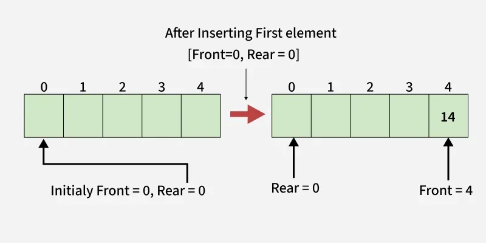

```python
def insertFront(self, key):
    if self.size == self.capacity:
        print("Deque is full")
        return
    self.front = (self.front - 1 + self.capacity) % self.capacity
    self.arr[self.front] = key
    self.size += 1
```

Hapus Elemen Dari Ujung Belakang Deque

- Pertama-tama kita periksa apakah deque kosong atau tidak.
- Jika ukuran == 0,

kembalikan (deque kosong)

- Atau hitung indeks belakang: belakang = (depan + ukuran - 1) % kapasitas
- Simpan elemen yang akan dihapus: res = arr[rear]
- Kurangi ukuran sebanyak 1
- Kembalikan elemen yang dihapus, res

```python
def deleteRear(self):
    if self.size == 0:
        print("Deque is empty")
        return -1
    rear = (self.front + self.size - 1) % self.capacity
    res = self.arr[rear]
    self.size -= 1
    return res
```

Hapus Elemen dari Antarmuka Depan Deque

- Pertama-tama kita periksa apakah deque kosong atau tidak.
- Jika ukuran == 0,

kembalikan (deque kosong)

- Simpan elemen depan: res = arr[front]
- Pindahkan indeks depan secara melingkar: depan = (depan + 1) % kapasitas
- Kurangi ukuran sebanyak 1

ukuran--

- Kembalikan elemen yang dihapus, res

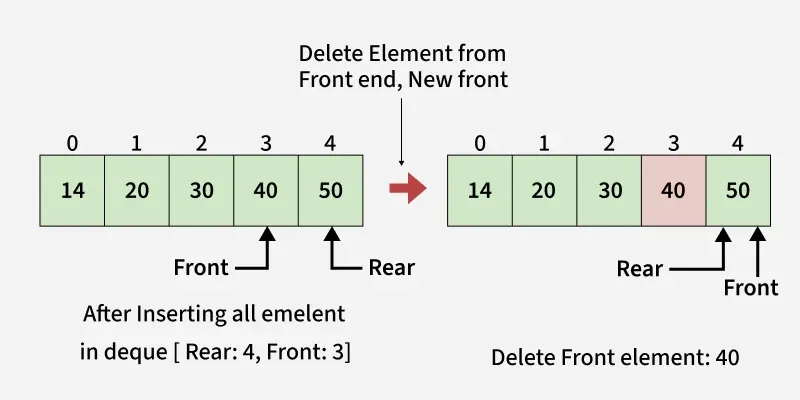

```python
def deleteFront(self):
    if self.size == 0:
        print("Deque is empty")
        return -1
    res = self.arr[self.front]
    self.front = (self.front + 1) % self.capacity
    self.size -= 1
    return res
```

Berikut adalah implementasi lengkapnya:

```python
class myDeque:

    # Constructor to initialize the deque with a given capacity
    def __init__(self, c):
        self.l = [None] * c
        self.cap = c
        self.size = 0
        self.front = 0

    # Delete element from the front
    def deleteFront(self):

        # Return None if deque is empty
        if self.size == 0:
            return None
        else:
            res = self.l[self.front]

            # Move front index circularly
            self.front = (self.front + 1) % self.cap
            self.size -= 1
            return res

    # Insert element at the front
    def insertFront(self, x):
        # Return if deque is full
        if self.size == self.cap:
            return
        else:
            # Move front index circularly
            self.front = (self.front - 1 + self.cap) % self.cap
            self.l[self.front] = x
            self.size += 1

    # Insert element at the rear
    def insertRear(self, x):

        # Return if deque is full
        if self.size == self.cap:
            return

        # Calculate rear index
        new_rear = (self.front + self.size) % self.cap
        self.l[new_rear] = x
        self.size += 1

    # Delete element from the rear
    def deleteRear(self):
        sz = self.size
        # Return None if deque is empty
        if sz == 0:
            return None
        else:
            # Calculate rear index
            rear = (self.front + sz - 1) % self.cap
            self.size -= 1
            return self.l[rear]

    # Get the front element
    def frontEle(self):
        return self.l[self.front]

    # Get the rear element
    def rearEle(self):
        # Calculate rear index
        rear = (self.front + self.size - 1) % self.cap
        return self.l[rear]


if __name__ == "__main__":
    dq = myDeque(4)

    dq.insertRear(10)
    dq.insertFront(20)
    dq.insertRear(30)
    print("Front:", dq.frontEle(), ", Rear:", dq.rearEle())

    dq.deleteFront()
    print("Front:", dq.frontEle(), ", Rear:", dq.rearEle())

    dq.deleteRear()
    print("Front:", dq.frontEle(), ", Rear:", dq.rearEle())
```

```
Front: 20 , Rear: 30
Front: 10 , Rear: 30
Front: 10 , Rear: 10
```